# MTDT_Function_ClassifyR

Andy Wang, Andy Tran & Jamie Mickaill

01/02/2022

# Multi Tier Decision Tree for Clinical Diagnostics

This program aims to use a sequential, machine learning approach to build a forest of multi-level clinical diagnostic trees with multi-omics data. This will allow for comparison of the cost and accuracy of different sequences of predictive models. With this information, we hope to enable better informed decisions of diagnostic processes.

At each node of the tree, a machine learning model is used to establish the sample specific accuracy of health outcome predictions for a single layer of the multi-omics data (e.g. how accurate is the prediction for a single individual based on their histology data?). If the prediction can not be made with sufficient accuracy, the individual will progress to the next level where an alternative model and layer of the omics data will be used. Currently each layer is analysed seperately, such that we have analysis of multiple single-omics datasets (ensemble learning to be implemented ?)

(Andy Wang) There are differences in terms of how these predictors variables could be obtained, how invasive they could be acquired, and how much they cost. The goal here is to find an optimal testing sequence with the different input models that we have, balancing it with the tier model error rates (TSER), the difficulty and differences in their unit cost.

```r
#User Inputs

###############################################################################

#Choose the MultiAssayExperiment Object for performing classification
MultiAssayExperiment = COVID_MAE



#Properties for weighting
#(E.g. # of individuals retained or total cost of all tests performed at a given tier)
properties = c("TSA.retained", "Cost.Total")

#To be updated:
#Currently weighting function is incorrect: (scaled(P1) * W1) + (scaled(P1) * W2) + (scaled(PN) * WN)

#Weights for properties
#(E.g. evaluation of best tier defined by relative error * -0.5 + relative cost * -0.5 )
weights = c(0.5,-0.5)

#List of tier names
#For melanoma example: longRNA has too many features, we just want a single iTRAQ****
tierList = c( "RNAseq"  ,    "Luminex"   , "CITEseq")

#Sample specific error cutoffs
#(E.g. x | if the sample specific error of cross validated prediction is > x, the sample will 'progress' to the next tier. Lower cutoff = higher retention generally)
# ssercutoffList= list(c(0.4, 0.4, 0.4),c(0.6, 0.6, 0.6)) # -> For multi-threshold analysis
ssercutoffLists= list(c(0.2, 0.2, 0.2))

#Tier costs (e.g. price of performing test for an individual), Clinical also last index
tierUnitCosts = c(100, 500, 1000)

#Which tier to fix as first in Tree? (If any)
# e.g. fixedTier = "Clinical"
# fixedTier = "clinical"
fixedTier = "RNAseq"

#Choose whether CV needed?
#runtest() or runtests()?
runtestorruntests = "runtests"

#name of classifier/classes column in dataset
classes = "outcome_bin"

#Performance type (e.g. Sample Error)
performanceType = "Sample Error"


##Cross validation parameters (could create a list for each experiment)
crossValParams = CrossValParams(
    samplesSplits = "Permute k-Fold",
    permutations = 5,
    percentTest = 25,
    folds = 5,
    leave = 2,
    tuneMode = "none",
    parallelParams = bpparam()
)



##Data transformation parameters
# transformParams = TransformParams(transform, characteristics = DataFrame(), intermediate = character(0), ...)
transformParamsList = c(NULL,NULL,NULL)



##Feature selection parameters
# selectParams = SelectParams(featureSelection, characteristics = DataFrame(), minPresence = 1, intermediate = character(0), subsetToSelections = TRUE, tuneParams = list(nFeatures = seq(10, 100, 10), performanceType = "Balanced Error"), ...)
selectParamsList = c(SelectParams(),SelectParams(),SelectParams())


##Training Parameters -> Insert classifier here
# To do: make this easier for the user by creating a funciton which will return the selectParamsList based on a simple classifier name, e.g. "SVM" will return SelectParams(SVMtrainInterface, kernel = "linear")?
#TrainParams = TrainParams(classifier, characteristics = DataFrame(), intermediate = character(0), getFeatures = NULL, ...)
trainParamsList = c(TrainParams(SVMtrainInterface, kernel = "linear", tuneParams = list(cost = c(0.01, 0.1, 1, 10))),TrainParams(randomForestTrainInterface),TrainParams())

##Prediction Parameters -> Insert classifier here
# PredictParams(predictor, characteristics = DataFrame(), intermediate = character(0), ...)
predictParamsList = c(PredictParams(SVMpredictInterface),PredictParams(randomForestPredictInterface),PredictParams())

##Modelling params List
modellingParams = list()

for(model in 1:length(tierList)){
  currModellingParams = ModellingParams(
    balancing = "none",
    transformParams  = NULL,
    selectParams = selectParamsList[[model]],
    trainParams = trainParamsList[[model]],
    predictParams = predictParamsList[[model]],
    doImportance = FALSE
)

  modellingParams = c(modellingParams,currModellingParams)
}




#describing the characteristics of the classification used
# characteristics = S4Vectors::DataFrame()
#to do: make a list and test out some non-null values
characteristics = NULL

seed=1
verbose=3

###############################################################################
```

## Main Code

```
## [1] "(1) RNAseq-Luminex-CITEseq: <RNAseq>"
## [1] "RNAseq"
```

```
## harmonizing input:
##   removing 102 sampleMap rows not in names(experiments)
```

```
## harmonizing input:
##   removing 102 sampleMap rows not in names(experiments)
```

```
## Processing sample set 10.
```

```
## Processing sample set 20.
```

```
## [1] "Size Check"
## [1] "11"
## [1] "    Total = 51"
## [1] "    Processed =51 (40 retained, 11 to progress to next tier)"
## [1] "    Not processed = 0"
## [1] "(1) RNAseq-Luminex-CITEseq: <Luminex>"
## [1] "Luminex"
```

```
## harmonizing input:
##   removing 22 sampleMap rows not in names(experiments)
```

```
## harmonizing input:
##   removing 22 sampleMap rows not in names(experiments)
```

```
## Processing sample set 10.
```

```
## Processing sample set 20.
```

```
## [1] "Less than 10 samples to progress, classifying at current layer!"
## [1] "Size Check"
## [1] "0"
## [1] "    Total = 11"
## [1] "    Processed =11 (11 retained, 0 to progress to next tier)"
## [1] "    Not processed = 0"
## [1] "(1) RNAseq-Luminex-CITEseq: <CITEseq>"
## [1] "CITEseq"
```

```
## harmonizing input:
##   removing 2 sampleMap rows not in names(experiments)
##   removing 1 sampleMap rows with 'colname' not in colnames of experiments
```

```
## harmonizing input:
##   removing 2 sampleMap rows not in names(experiments)
##   removing 1 sampleMap rows with 'colname' not in colnames of experiments
```

```
## [1] 0
## [1] "Error: Low row count, unable to use CV"
## [1] "Less than 10 samples to progress, classifying at current layer!"
## [1] "Size Check"
## [1] "0"
## [1] "    Total = 0"
## [1] "    Processed =0 (0 retained, 0 to progress to next tier)"
## [1] "    Not processed = 0"
## [1] "(2) RNAseq-CITEseq-Luminex: <RNAseq>"
## [1] "RNAseq"
```

```
## harmonizing input:
##   removing 102 sampleMap rows not in names(experiments)
```

```
## harmonizing input:
##   removing 102 sampleMap rows not in names(experiments)
```

```
## Processing sample set 10.
```

```
## Processing sample set 20.
```

```
## [1] "Size Check"
## [1] "12"
## [1] "    Total = 51"
## [1] "    Processed =51 (39 retained, 12 to progress to next tier)"
## [1] "    Not processed = 0"
## [1] "(2) RNAseq-CITEseq-Luminex: <CITEseq>"
## [1] "CITEseq"
```

```
## harmonizing input:
##   removing 24 sampleMap rows not in names(experiments)
```

```
## harmonizing input:
##   removing 24 sampleMap rows not in names(experiments)
## Processing sample set 20.
```

[output not shown]

```
## [1] "Size Check"
## [1] "12"
## [1] "    Total = 12"
## [1] "    Processed =12 (0 retained, 12 to progress to next tier)"
## [1] "    Not processed = 0"
## [1] "(2) RNAseq-CITEseq-Luminex: <Luminex>"
## [1] "Luminex"
```

```
## harmonizing input:
##   removing 24 sampleMap rows not in names(experiments)
```

```
## harmonizing input:
##   removing 24 sampleMap rows not in names(experiments)
## Processing sample set 10.
```

```
## Processing sample set 20.
```

```
## [1] "Less than 10 samples to progress, classifying at current layer!"
## [1] "Size Check"
## [1] "0"
## [1] "    Total = 12"
## [1] "    Processed =12 (12 retained, 0 to progress to next tier)"
## [1] "    Not processed = 0"
## # A tibble: 2 × 2
##    tser strata
##   <dbl> <fct>
## 1 0.937 Retained
## 2 0.164 Not retained
## [1] 1
## # A tibble: 51 × 6
##    SampleID      sser strata   `SSER$removed` tier      ID
##    <chr>        <dbl> <fct>    <chr>          <chr>  <int>
##  1 G05064-Ja005     0 Retained <NA>           RNAseq     1
##  2 G05073-Ja005     0 Retained <NA>           RNAseq     2
##  3 S00005-Ja005     0 Retained <NA>           RNAseq     3
##  4 S00006-Ja005     0 Retained <NA>           RNAseq     4
##  5 S00007-Ja003     0 Retained <NA>           RNAseq     5
##  6 S00008-Ja003     0 Retained <NA>           RNAseq     6
##  7 S00020-Ja003     0 Retained <NA>           RNAseq     7
##  8 S00024-Ja003     0 Retained <NA>           RNAseq     8
##  9 S00027-Ja003     0 Retained <NA>           RNAseq     9
## 10 S00028-Ja001     0 Retained <NA>           RNAseq    10
## # … with 41 more rows
## [1] 2
## # A tibble: 11 × 6
##    SampleID      sser strata   `SSER$removed` tier       ID
##    <chr>        <dbl> <fct>    <chr>          <chr>   <int>
##  1 S00002-Ja001     0 Retained <NA>           Luminex    41
##  2 S00016-Ja001     0 Retained <NA>           Luminex    42
##  3 S00059-Ja001     0 Retained <NA>           Luminex    43
##  4 S00063-Ja003     0 Retained <NA>           Luminex    44
##  5 S00076-Ja001     0 Retained <NA>           Luminex    45
##  6 S00104-Ja003     0 Retained <NA>           Luminex    46
##  7 S00112-Ja003     0 Retained <NA>           Luminex    47
##  8 S00113-Ja005     0 Retained <NA>           Luminex    48
##  9 S00064-Ja005     1 Retained <NA>           Luminex    49
## 10 S00078-Ja003     1 Retained <NA>           Luminex    50
```

[output cut: 67 more lines]

```
## 1 RNAseq     51 25500
## 2 CITEseq    12  1200
## 3 Luminex    12 12000
## # A tibble: 2 × 3
##   Tier.Sequence          Cost.byTier         Cost.Total
##   <chr>                  <chr>                    <dbl>
## 1 RNAseq-Luminex-CITEseq $25500-$1100             26600
## 2 RNAseq-CITEseq-Luminex $25500-$1200-$12000      38700
## # A tibble: 2 × 10
##   Tier.Sequence    TSA.retained TSA.notretained N.Total N.retained N.notretained
##   <chr>                   <dbl>           <dbl>   <int>      <int>         <int>
## 1 RNAseq-Luminex-…       0.0627           0.836      51         51             0
## 2 RNAseq-CITEseq-…       0.0980           0.817      51         51             0
## # … with 4 more variables: Prop.notretained <dbl>, Threshold <dbl>,
## #   Cost.byTier <chr>, Cost.Total <dbl>
```

## Plots

Updates

- Accuracy instead of Error
- Changes axis on bubble plot (from y = retention to y = cost)
- Concentric bubbles to represent tier retention proportions
- Table -> remove proportion retained but keep total accuracy?

New plots

- Tree plot with numbers of samples progressed represented on edge lines

```
## [1] "\n"
## [1] "RNAseq-Luminex-CITEseq"
## [1] "\n"
##                    levelName counter tierOrder
## 1 RNAseq                          NA        NA
## 2  ¦--Retained (RNAseq)           40         1
## 3  °--To progress (RNAseq)        11         1
## 4      °--Retained (Luminex)      11         2
## [1] 0.7843137
## [1] 1
## [1] "\n"
## [1] "RNAseq-CITEseq-Luminex"
## [1] "\n"
##                        levelName counter tierOrder
## 1 RNAseq                              NA        NA
## 2  ¦--Retained (RNAseq)               39         1
## 3  °--To progress (RNAseq)            12         1
## 4      °--To progress (CITEseq)       12         2
## 5          °--Retained (Luminex)      12         3
## [1] 0.7647059
## [1] 1
```

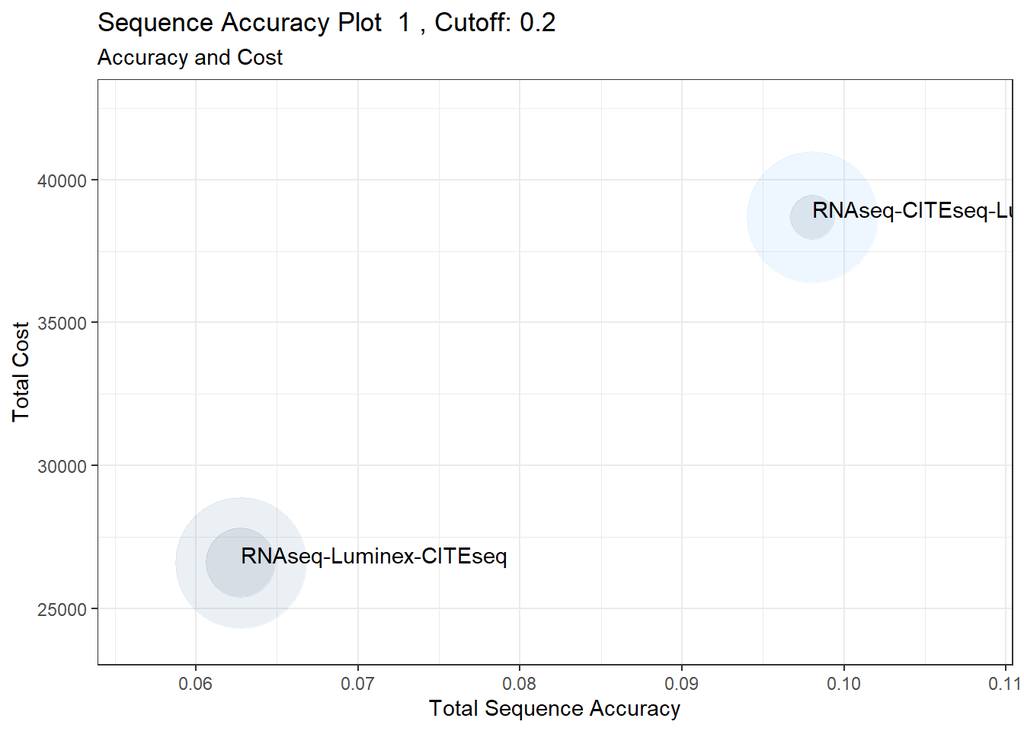

|  | Tier.Sequence | TSA.retained | N.Total | Threshold | Cost.byTier | Cost.Total | Weight |
| --- | --- | --- | --- | --- | --- | --- | --- |
| 1 | RNAseq-Luminex-CITEseq | 0.0627450980392157 | 51 | 0.2 | $25500-$1100 | 26600 | 0 |
| 2 | RNAseq-CITEseq-Luminex | 0.0980392156862745 | 51 | 0.2 | $25500-$1200-$12000 | 38700 | 0 |

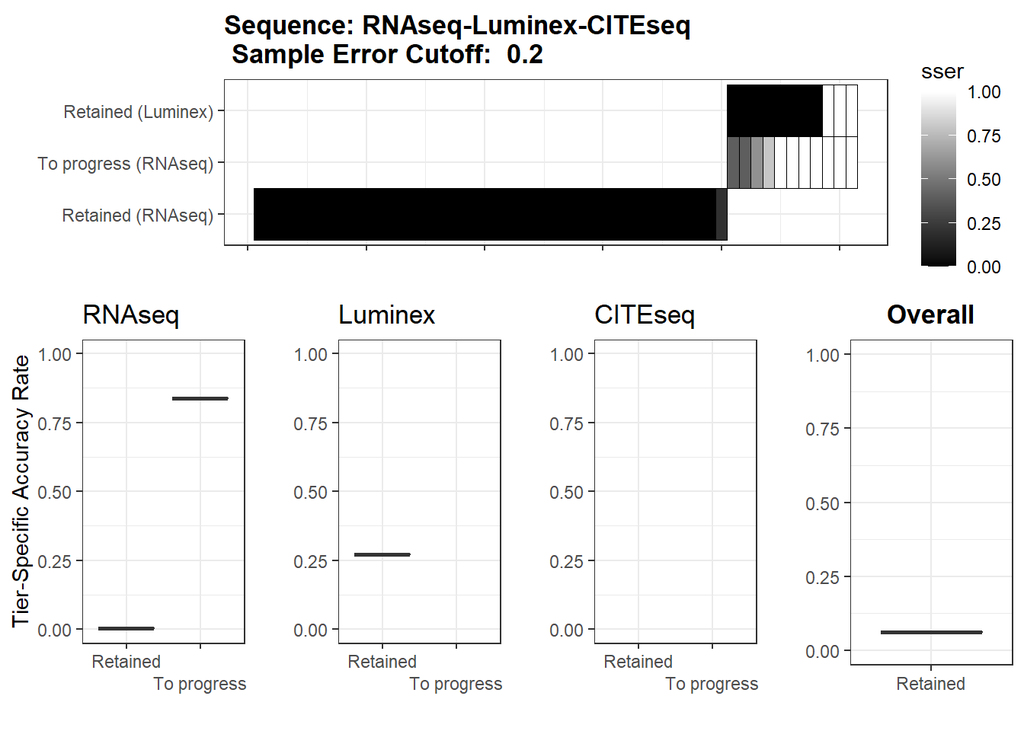

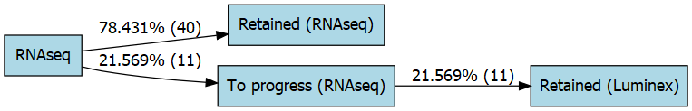

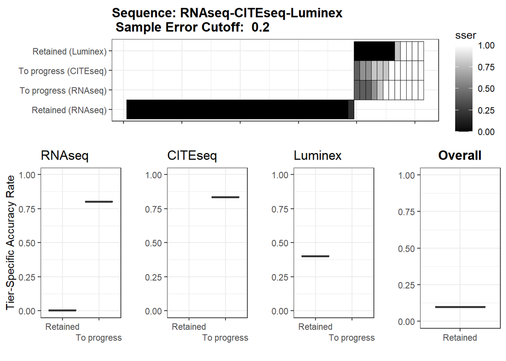

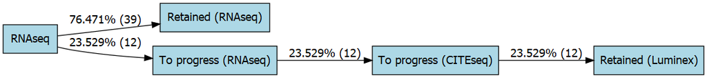